# Assignment 2

## Season B

### 1. Loading Data

```r
y <- Y[,7]
# Transform it into a time series
y <- ts(y,frequency=12)
```

### 2. Constructing estimation and hold-out sets

```r
y.tst <- tail(y,12)
y.trn <- head(y,48)
```

### 3. Exploration

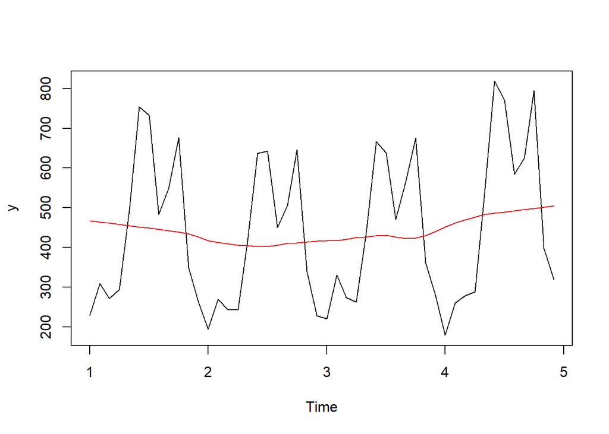

```r
cma <- cmav(y.trn,outplot=1)
```

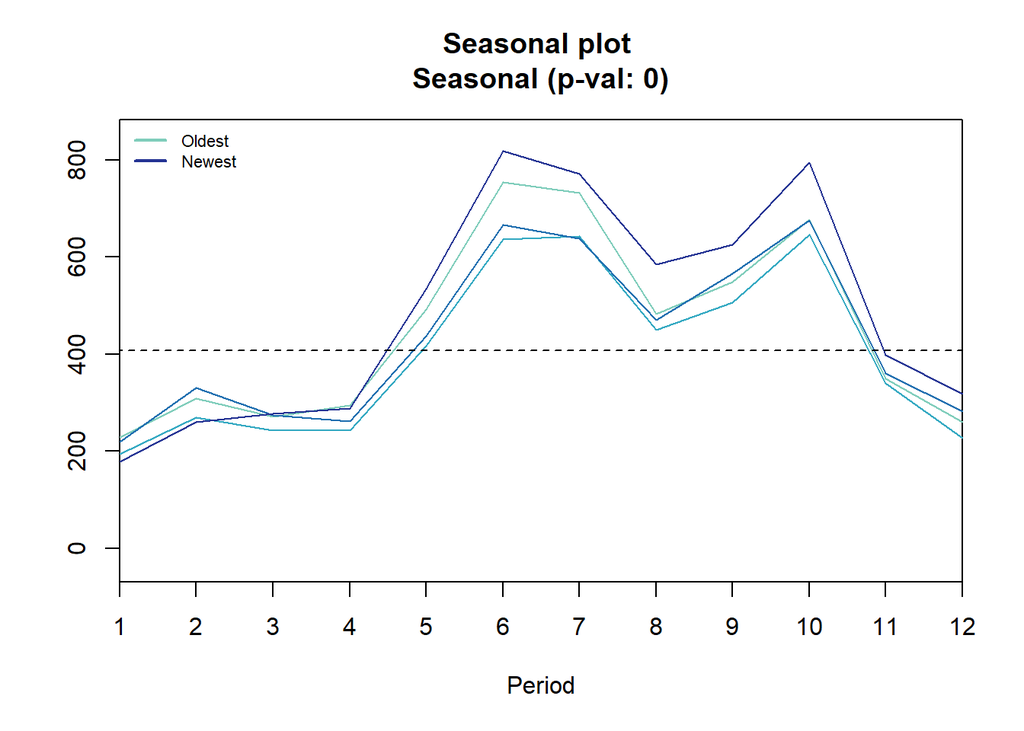

```
## Results of statistical testing
## Evidence of trend: FALSE  (pval: 0.419)
## Evidence of seasonality: TRUE  (pval: 0)
```

```r
seasplot(y.trn)
```

### 4. Forecasting

#### 4.1 Model fitting

```r
# Automatic Alpha ANN
fit <- ets(y.trn,model="ANN")
print(fit)
```

```
## ETS(A,N,N)
##
## Call:
##  ets(y = y.trn, model = "ANN")
##
##   Smoothing parameters:
##     alpha = 0.9999
##
##   Initial states:
##     l = 229.1407
##
##   sigma:  162.5972
##
##      AIC     AICc      BIC
## 678.5373 679.0827 684.1509
```

```r
# Alpha M1 ANN
fit_m1 <- ets(y.trn,model="ANN", alpha = 0.7 )
print(fit_m1)
```

```
## ETS(A,N,N)
##
## Call:
##  ets(y = y.trn, model = "ANN", alpha = 0.7)
##
##   Smoothing parameters:
##     alpha = 0.7
##
##   Initial states:
##     l = 252.2465
##
##   sigma:  169.5319
##
##      AIC     AICc      BIC
## 680.5467 680.8134 684.2891
```

```r
# Alpha M2 ANN
fit_m2 <- ets(y.trn,model="ANN", alpha = 0.4 )
print(fit_m2)
```

```
## ETS(A,N,N)
##
## Call:
##  ets(y = y.trn, model = "ANN", alpha = 0.4)
##
##   Smoothing parameters:
##     alpha = 0.4
##
##   Initial states:
##     l = 306.8874
##
##   sigma:  185.4211
##
##      AIC     AICc      BIC
## 689.1472 689.4139 692.8896
```

```r
cirt <- array(NA, c(3, 4), dimnames = list(c("Automatic", "M1", "M2"),
                                         c("MSE", "AIC", "AICc","BIC")))

models <- list(fit, fit_m1, fit_m2)

for (i in 1:3) {
  cirt[i, "MSE"] <- models[[i]]$mse
  cirt[i, "AIC"] <- models[[i]]$aic
  cirt[i, "AICc"] <- models[[i]]$aicc
  cirt[i, "BIC"] <- models[[i]]$bic
}

print(cirt)
```

```
##                MSE      AIC     AICc      BIC
## Automatic 25336.28 678.5373 679.0827 684.1509
## M1        27543.51 680.5467 680.8134 684.2891
## M2        32948.45 689.1472 689.4139 692.8896
```

#### 4.2 Forecasting

- Forecast ANN

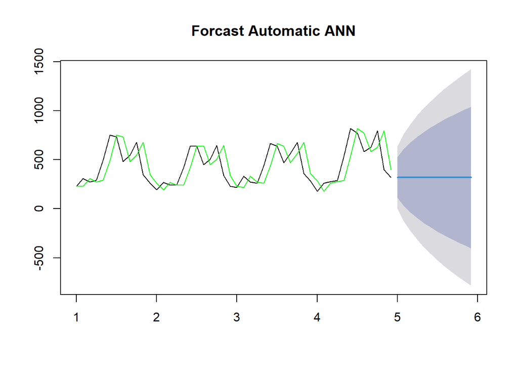

```r
# ploting Automatic ANN
frc <- forecast(fit, h=12)
plot(frc, main = "Forcast Automatic ANN")
lines(fit$fitted,col="green")
```

- Forecast ANN and Alpha M1

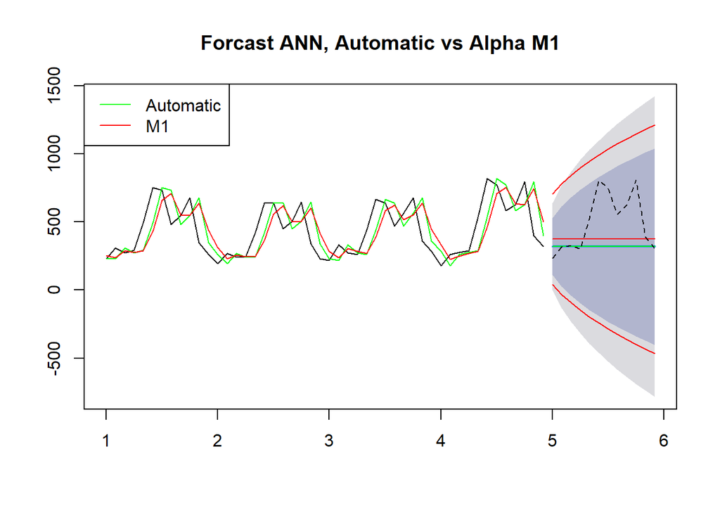

```r
# ploting M1 vs ANN
frc_m1 <- forecast(fit_m1,h=12)
plot(frc, main = "Forcast ANN, Automatic vs Alpha M1")
lines(frc$mean,col="green")
lines(fit$fitted,col="green")
lines(fit_m1$fitted,col="red")

lines(frc_m1$mean,col="red")
lines(frc_m1$lower[,2],col="red") # 95% lower
lines(frc_m1$upper[,2],col="red") # 95% upper
lines(y.tst,lty=2)

# legends
legend("topleft",c("Automatic","M1"),col=c("green","red"),lty=1)
```

- Forecast ANN and Alpha M2

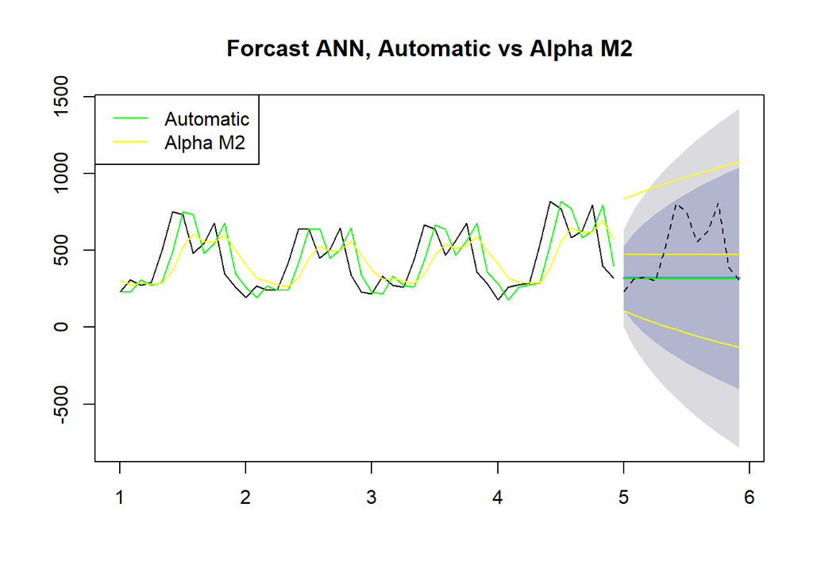

```r
# Ploting M2 vs ANN
frc_m2 <- forecast(fit_m2,h=12)
plot(frc, main = "Forcast ANN, Automatic vs Alpha M2")
lines(frc$mean,col="green")
lines(fit$fitted,col="green")
lines(fit_m2$fitted,col="yellow")

lines(frc_m2$mean,col="yellow")
lines(frc_m2$lower[,2],col="yellow") # 95% lower
lines(frc_m2$upper[,2],col="yellow") # 95% upper
lines(y.tst,lty=2)

# Add legend to the plot
legend("topleft",c("Automatic","Alpha M2"),col=c("green","yellow"),lty=1)
```

- Confidence level ANN, Alpha M1 and Alpha M2

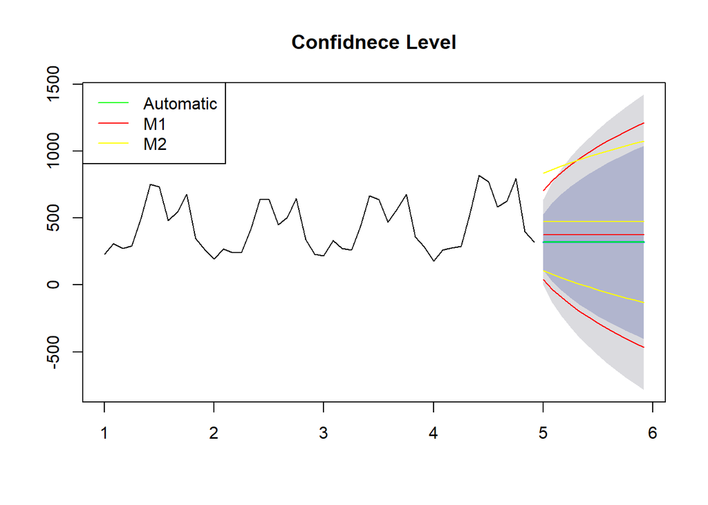

```r
# Ploting confidence level of all 3
plot(frc, main = "Confidnece Level")
lines(frc$mean,col="green")

lines(frc_m1$mean,col="red")
lines(frc_m1$lower[,2],col="red") # 95% lower
lines(frc_m1$upper[,2],col="red")

lines(frc_m2$mean,col="yellow")
lines(frc_m2$lower[,2],col="yellow") # 95% lower
lines(frc_m2$upper[,2],col="yellow") # 95% upper

# Add legend to the plot
legend("topleft",c("Automatic","M1","M2"),col=c("green","red","yellow"),lty=1)
```

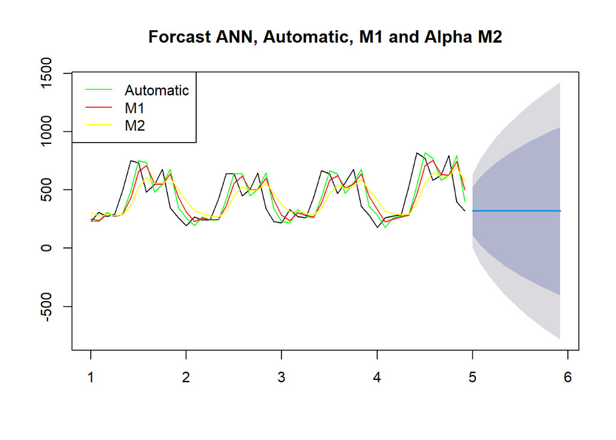

```r
plot(frc, main = "Forcast ANN, Automatic, M1 and Alpha M2")
lines(fit$fitted,col="green")
lines(fit_m1$fitted,col="red")
lines(fit_m2$fitted,col="yellow")
legend("topleft",c("Automatic","M1","M2"),col=c("green","red","yellow"),lty=1)
```

#### 4.3 Model selection

```r
# Function to calculate metrics
calculate_metrics <- function(y, frc) {
  MAE <- mean(abs(y - frc$mean))
  MSE <- mean((y - frc$mean)^2)
  RMSE <- sqrt(MSE)
  return(list(MAE = MAE, MSE = MSE, RMSE = RMSE))
}

# Calculate metrics for different forecasts
metrics_a <- calculate_metrics(y.tst, frc)
metrics_m1 <- calculate_metrics(y.tst, frc_m1)
metrics_m2 <- calculate_metrics(y.tst, frc_m2)

# Create a matrix for the metrics
metrics_matrix <- matrix(c(metrics_a$MAE, metrics_m1$MAE, metrics_m2$MAE,
                           metrics_a$RMSE, metrics_m1$RMSE, metrics_m2$RMSE,
                          metrics_a$MSE, metrics_m1$MSE, metrics_m2$MSE),
                          ncol = 3, byrow = TRUE)

# Add row and column names
rownames(metrics_matrix) <- c("MAE", "MSE", "RMSE")
colnames(metrics_matrix) <- c("Automatic", "Alpha M1", "Alpha M2")

# Display the metrics matrix
metrics_matrix
```

```
##       Automatic   Alpha M1   Alpha M2
## MAE    196.4063   185.6204   183.5548
## MSE    268.7739   236.4825   204.4416
## RMSE 72239.4193 55923.9927 41796.3854
```

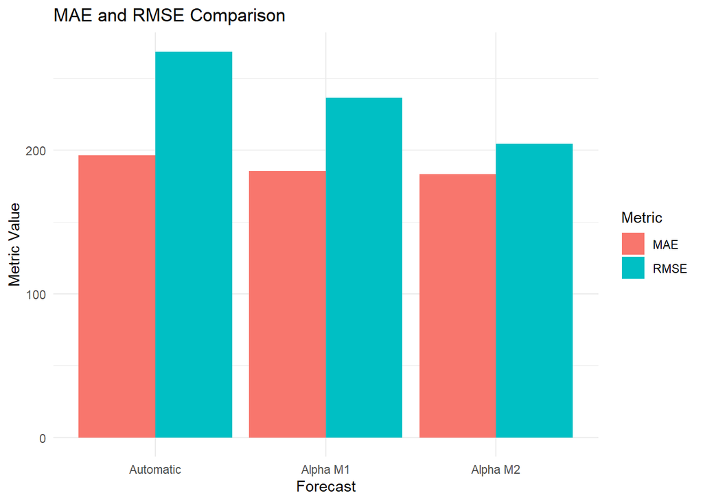

```r
# Create a data frame from the metrics matrix, excluding MSE
metrics_df <- data.frame(
  Metric = rep(c("MAE", "RMSE"), each = 3),
  Value = c(metrics_a$MAE, metrics_m1$MAE, metrics_m2$MAE,
            metrics_a$RMSE, metrics_m1$RMSE, metrics_m2$RMSE),
  Forecast = rep(c("Automatic", "Alpha M1", "Alpha M2"), times = 2)
)
metrics_df$Forecast <- factor(metrics_df$Forecast, levels = c("Automatic", "Alpha M1", "Alpha M2"))

# Create a bar plot
ggplot(metrics_df, aes(x = Forecast, y = Value, fill = Metric)) +
  geom_bar(stat = "identity", position = position_dodge()) +
  labs(title = "MAE and RMSE Comparison",
       y = "Metric Value") +
  theme_minimal()
```

### 5. Answers

- Which one is best using your judgement?

  In the context of modeling the “Season_B” component within the in-sample data, it is observed that Model M1 excels in filtering out noise and outliers while providing a good fit to the data. Comparatively, Model M2, although successful in noise and outlier reduction, falls short in capturing the seasonality effectively. The automatic model, while fitting the data well in terms of seasonality, struggles to filter out noise and outliers.

  Given these considerations, the judgment leans toward **Model M1** as it achieves a balance between noise reduction and fitting performance.
- Which one is best using errors?

  The error metrics, MSE and AIC, suggest that the **Automatic** model performs better in terms of error minimization. This implies that the automatic model provides the most accurate predictions for the “Season_B” component within the in-sample data.
- Does the selected model perform best in the out-of-sample data?

  In the out-of-sample analysis, Model M1 does not emerge as the best choice, as it does not yield the best RMSE and MAE values. **Model M2** exhibits superior performance in terms of these metrics.

  It is essential to acknowledge that while Model M1 excels in filtering out noise and outliers in the in-sample data while fitting well, its out-of-sample performance may differ. Model M2, despite its limitations in fitting, appears to generalize better to unseen data points for forecasting “Season_B.”

## Trend Season

### 1. Loading Data

```r
y <- Y[,8]
# Transform it into a time series
y <- ts(y,frequency=12)
```

### 2. Constructing estimation and hold-out sets

```r
y.tst <- tail(y,12)
y.trn <- head(y,48)
```

### 3. Exploration

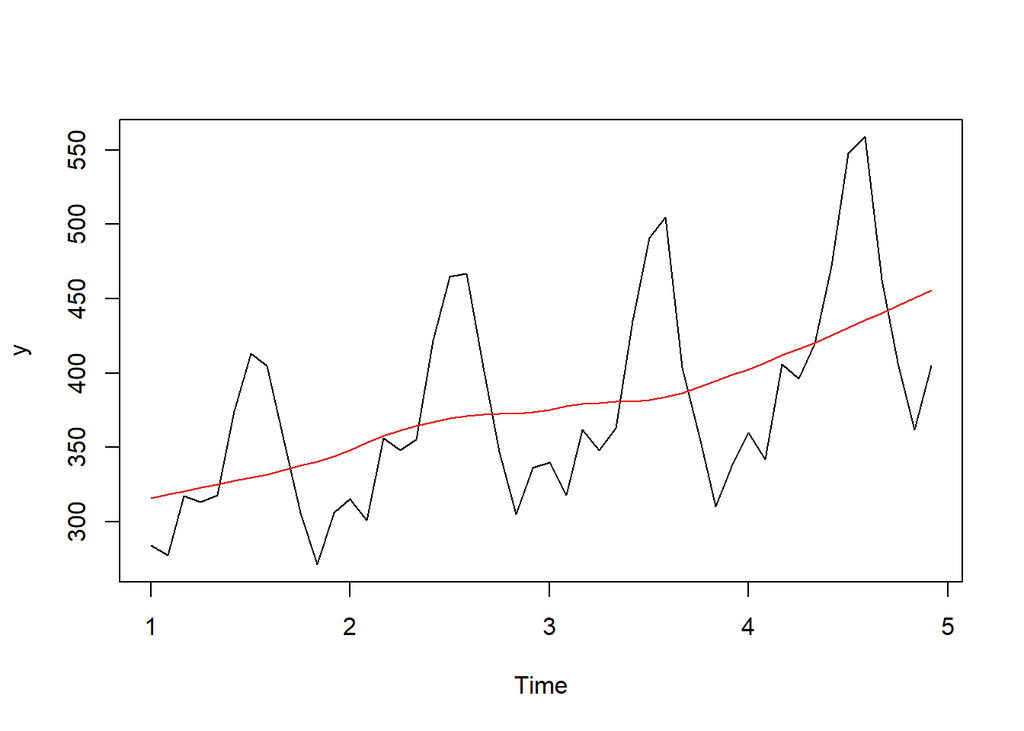

```r
cma <- cmav(y.trn,outplot=1)
```

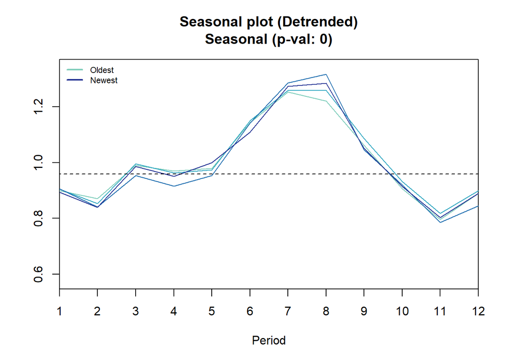

```
## Results of statistical testing
## Evidence of trend: TRUE  (pval: 0)
## Evidence of seasonality: TRUE  (pval: 0)
```

```r
seasplot(y.trn)
```

### 4. Forecasting

#### 4.1 Model fitting

```r
# Automatic Alpha ANN
fit <- ets(y.trn,model="ANN")
print(fit)
```

```
## ETS(A,N,N)
##
## Call:
##  ets(y = y.trn, model = "ANN")
##
##   Smoothing parameters:
##     alpha = 0.9999
##
##   Initial states:
##     l = 334.407
##
##   sigma:  45.0096
##
##      AIC     AICc      BIC
## 555.2349 555.7803 560.8485
```

```r
# Alpha M1 ANN
fit_m1 <- ets(y.trn,model="ANN", alpha = 0.7 )
print(fit_m1)
```

```
## ETS(A,N,N)
##
## Call:
##  ets(y = y.trn, model = "ANN", alpha = 0.7)
##
##   Smoothing parameters:
##     alpha = 0.7
##
##   Initial states:
##     l = 285.6387
##
##   sigma:  50.046
##
##      AIC     AICc      BIC
## 563.4173 563.6840 567.1597
```

```r
# Alpha M2 ANN
fit_m2 <- ets(y.trn,model="ANN", alpha = 0.4 )
print(fit_m2)
```

```
## ETS(A,N,N)
##
## Call:
##  ets(y = y.trn, model = "ANN", alpha = 0.4)
##
##   Smoothing parameters:
##     alpha = 0.4
##
##   Initial states:
##     l = 298.5088
##
##   sigma:  57.9453
##
##      AIC     AICc      BIC
## 577.4867 577.7534 581.2291
```

```r
cirt <- array(NA, c(3, 4), dimnames = list(c("Automatic", "M1", "M2"),
                                         c("MSE", "AIC", "AICc","BIC")))

models <- list(fit, fit_m1, fit_m2)

for (i in 1:3) {
  cirt[i, "MSE"] <- models[[i]]$mse
  cirt[i, "AIC"] <- models[[i]]$aic
  cirt[i, "AICc"] <- models[[i]]$aicc
  cirt[i, "BIC"] <- models[[i]]$bic
}

print(cirt)
```

```
##                MSE      AIC     AICc      BIC
## Automatic 1941.454 555.2349 555.7803 560.8485
## M1        2400.245 563.4173 563.6840 567.1597
## M2        3217.755 577.4867 577.7534 581.2291
```

#### 4.2 Forecasting

- Forecast ANN

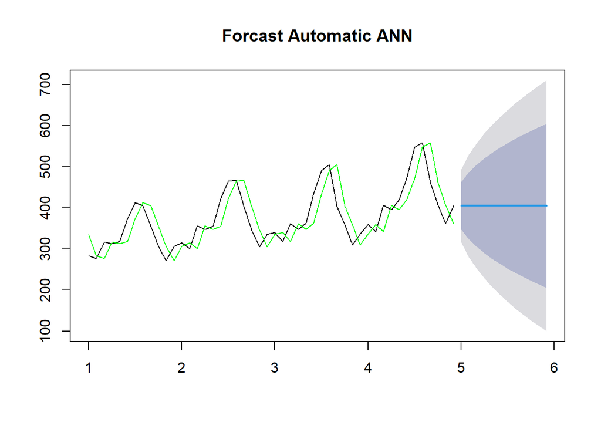

```r
# ploting Automatic ANN
frc <- forecast(fit, h=12)
plot(frc, main = "Forcast Automatic ANN")
lines(fit$fitted,col="green")
```

- Forecast ANN and Alpha M1

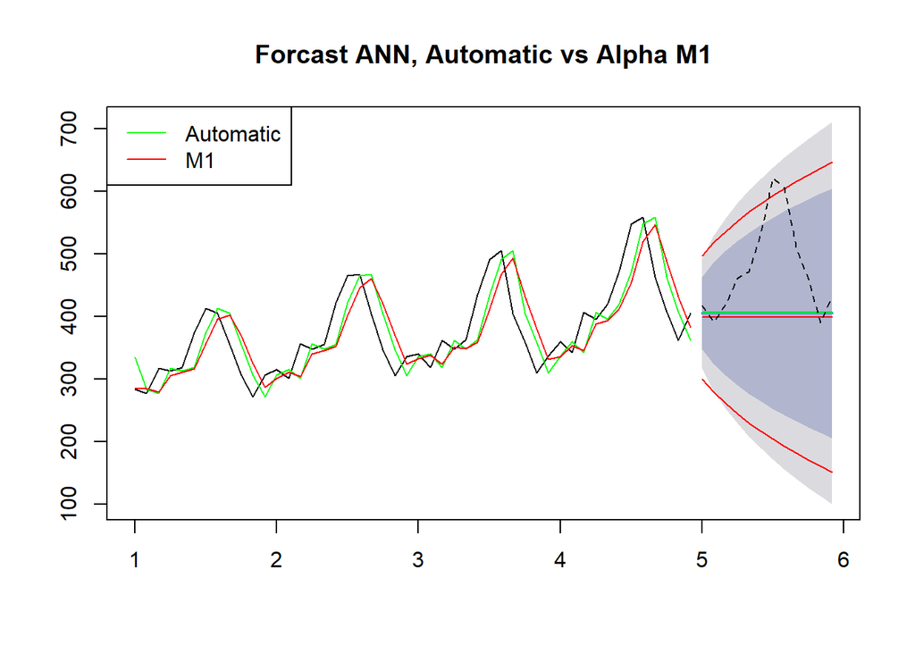

```r
# ploting M1 vs ANN
frc_m1 <- forecast(fit_m1,h=12)
plot(frc, main = "Forcast ANN, Automatic vs Alpha M1")
lines(frc$mean,col="green")
lines(fit$fitted,col="green")
lines(fit_m1$fitted,col="red")

lines(frc_m1$mean,col="red")
lines(frc_m1$lower[,2],col="red") # 95% lower
lines(frc_m1$upper[,2],col="red") # 95% upper
lines(y.tst,lty=2)

# legends
legend("topleft",c("Automatic","M1"),col=c("green","red"),lty=1)
```

- Forecast ANN and Alpha M2

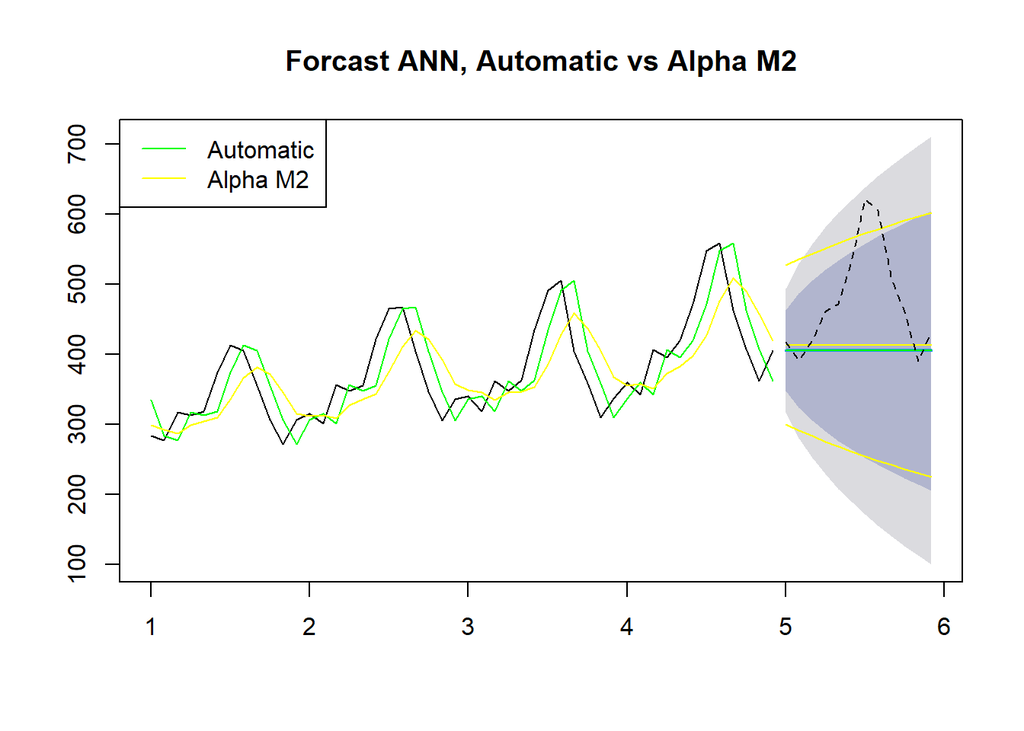

```r
# Ploting M2 vs ANN
frc_m2 <- forecast(fit_m2,h=12)
plot(frc, main = "Forcast ANN, Automatic vs Alpha M2")
lines(frc$mean,col="green")
lines(fit$fitted,col="green")
lines(fit_m2$fitted,col="yellow")

lines(frc_m2$mean,col="yellow")
lines(frc_m2$lower[,2],col="yellow") # 95% lower
lines(frc_m2$upper[,2],col="yellow") # 95% upper
lines(y.tst,lty=2)

# Add legend to the plot
legend("topleft",c("Automatic","Alpha M2"),col=c("green","yellow"),lty=1)
```

- Confidence level ANN, Alpha M1 and Alpha M2

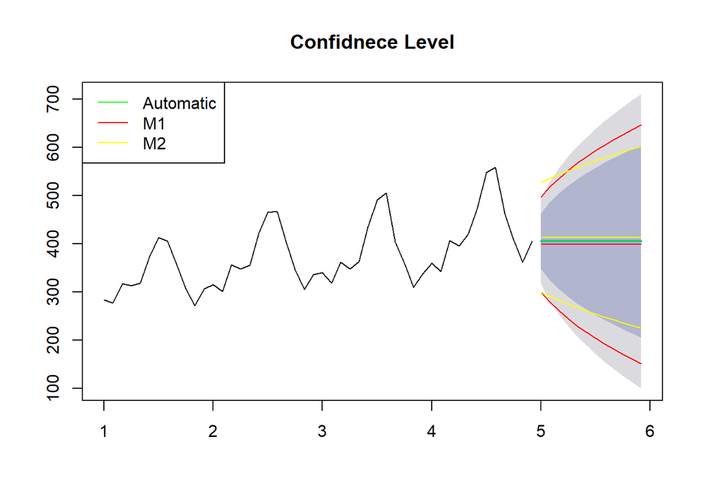

```r
# Ploting confidence level of all 3
plot(frc, main = "Confidnece Level")
lines(frc$mean,col="green")

lines(frc_m1$mean,col="red")
lines(frc_m1$lower[,2],col="red") # 95% lower
lines(frc_m1$upper[,2],col="red")

lines(frc_m2$mean,col="yellow")
lines(frc_m2$lower[,2],col="yellow") # 95% lower
lines(frc_m2$upper[,2],col="yellow") # 95% upper

# Add legend to the plot
legend("topleft",c("Automatic","M1","M2"),col=c("green","red","yellow"),lty=1)
```

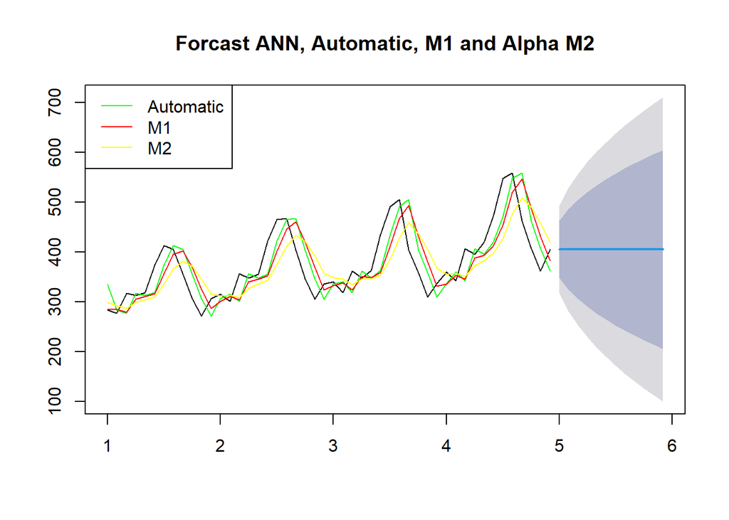

```r
plot(frc, main = "Forcast ANN, Automatic, M1 and Alpha M2")
lines(fit$fitted,col="green")
lines(fit_m1$fitted,col="red")
lines(fit_m2$fitted,col="yellow")
legend("topleft",c("Automatic","M1","M2"),col=c("green","red","yellow"),lty=1)
```

#### 4.3 Model selection

```r
# Function to calculate metrics
calculate_metrics <- function(y, frc) {
  MAE <- mean(abs(y - frc$mean))
  MSE <- mean((y - frc$mean)^2)
  RMSE <- sqrt(MSE)
  return(list(MAE = MAE, MSE = MSE, RMSE = RMSE))
}

# Calculate metrics for different forecasts
metrics_a <- calculate_metrics(y.tst, frc)
metrics_m1 <- calculate_metrics(y.tst, frc_m1)
metrics_m2 <- calculate_metrics(y.tst, frc_m2)

# Create a matrix for the metrics
metrics_matrix <- matrix(c(metrics_a$MAE, metrics_m1$MAE, metrics_m2$MAE,
                           metrics_a$RMSE, metrics_m1$RMSE, metrics_m2$RMSE,
                          metrics_a$MSE, metrics_m1$MSE, metrics_m2$MSE),
                          ncol = 3, byrow = TRUE)

# Add row and column names
rownames(metrics_matrix) <- c("MAE", "MSE", "RMSE")
colnames(metrics_matrix) <- c("Automatic", "Alpha M1", "Alpha M2")

# Display the metrics matrix
metrics_matrix
```

```
##        Automatic   Alpha M1   Alpha M2
## MAE     76.00287    80.4371   70.36908
## MSE    102.97951   107.6837   97.33092
## RMSE 10604.77875 11595.7842 9473.30712
```

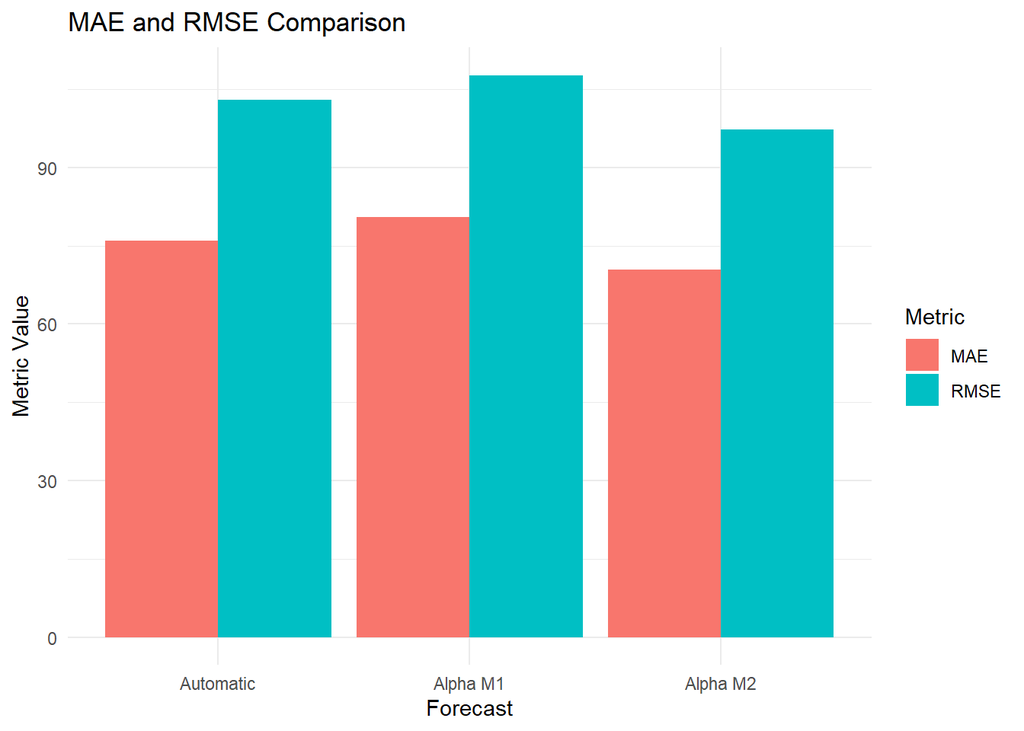

```r
# Create a data frame from the metrics matrix, excluding MSE
metrics_df <- data.frame(
  Metric = rep(c("MAE", "RMSE"), each = 3),
  Value = c(metrics_a$MAE, metrics_m1$MAE, metrics_m2$MAE,
            metrics_a$RMSE, metrics_m1$RMSE, metrics_m2$RMSE),
  Forecast = rep(c("Automatic", "Alpha M1", "Alpha M2"), times = 2)
)
metrics_df$Forecast <- factor(metrics_df$Forecast, levels = c("Automatic", "Alpha M1", "Alpha M2"))

# Create a bar plot
ggplot(metrics_df, aes(x = Forecast, y = Value, fill = Metric)) +
  geom_bar(stat = "identity", position = position_dodge()) +
  labs(title = "MAE and RMSE Comparison",
       y = "Metric Value") +
  theme_minimal()
```

### 5. Answers

- Which one is best using your judgement?

  When analyzing the in-sample data for the “TrendSeason” component, it becomes evident that **Model M1** effectively filters out noise and outliers while achieving a satisfactory fit compared to the Automatic model. Conversely, Model M2, while excelling in noise and outlier reduction, falls short in capturing the seasonality pattern effectively. The Automatic model, though capable of capturing seasonality, does not effectively filter out noise and outliers.
- Which one is best using errors?

  Examining error metrics such as MSE and AIC, it becomes apparent that the **Automatic** model performs better in terms of error minimization. This indicates that the Automatic model provides the most accurate predictions for the “TrendSeason” component within the in-sample data.
- Does the selected model perform best in the out-of-sample data?

  In the out-of-sample analysis, Model M1 does not emerge as the optimal choice. It does not yield the best RMSE and MAE values. On the contrary, Model M2 demonstrates superior performance in terms of these metrics.

  It is important to note that while Model M1 excels in filtering out noise and outliers and provides a good fit within the in-sample data, its out-of-sample performance may vary. **Model M2**, despite its limitations in capturing seasonality during fitting, appears to generalize better to unseen data points when forecasting “TrendSeason.

## AirPassenger

### 1. Loading Data

```r
y <- AirPassengers
# Transform it into a time series
y <- ts(y,frequency=12)
```

### 2. Constructing estimation and hold-out sets

```r
y.tst <- tail(y,29)
y.trn <- head(y,115)
```

### 3. Exploration

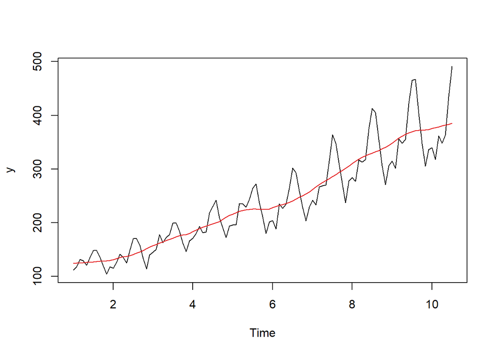

```r
cma <- cmav(y.trn,outplot=1)
```

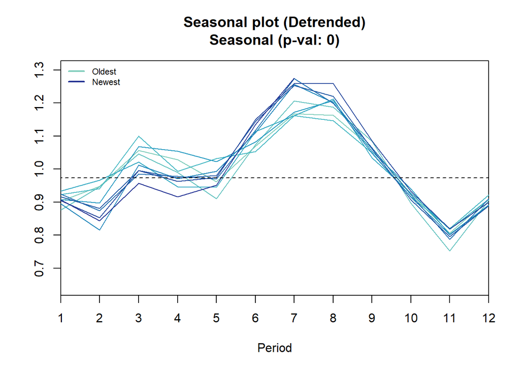

```
## Results of statistical testing
## Evidence of trend: TRUE  (pval: 0)
## Evidence of seasonality: TRUE  (pval: 0)
```

```r
seasplot(y.trn)
```

### 4. Forecasting

#### 4.1 Model fitting

```r
# Automatic Alpha ANN
fit <- ets(y.trn,model="ANN")
print(fit)
```

```
## ETS(A,N,N)
##
## Call:
##  ets(y = y.trn, model = "ANN")
##
##   Smoothing parameters:
##     alpha = 0.9999
##
##   Initial states:
##     l = 112.0508
##
##   sigma:  27.0371
##
##      AIC     AICc      BIC
## 1308.008 1308.224 1316.243
```

```r
# Alpha M1 ANN
fit_m1 <- ets(y.trn,model="ANN", alpha = 0.7 )
print(fit_m1)
```

```
## ETS(A,N,N)
##
## Call:
##  ets(y = y.trn, model = "ANN", alpha = 0.7)
##
##   Smoothing parameters:
##     alpha = 0.7
##
##   Initial states:
##     l = 114.9947
##
##   sigma:  30.1427
##
##      AIC     AICc      BIC
## 1331.016 1331.124 1336.506
```

```r
# Alpha M2 ANN
fit_m2 <- ets(y.trn,model="ANN", alpha = 0.4 )
print(fit_m2)
```

```
## ETS(A,N,N)
##
## Call:
##  ets(y = y.trn, model = "ANN", alpha = 0.4)
##
##   Smoothing parameters:
##     alpha = 0.4
##
##   Initial states:
##     l = 120.065
##
##   sigma:  34.8518
##
##      AIC     AICc      BIC
## 1364.404 1364.511 1369.894
```

```r
cirt <- array(NA, c(3, 4), dimnames = list(c("Automatic", "M1", "M2"),
                                         c("MSE", "AIC", "AICc","BIC")))

models <- list(fit, fit_m1, fit_m2)

for (i in 1:3) {
  cirt[i, "MSE"] <- models[[i]]$mse
  cirt[i, "AIC"] <- models[[i]]$aic
  cirt[i, "AICc"] <- models[[i]]$aicc
  cirt[i, "BIC"] <- models[[i]]$bic
}

print(cirt)
```

```
##                 MSE      AIC     AICc      BIC
## Automatic  718.2927 1308.008 1308.224 1316.243
## M1         892.7806 1331.016 1331.124 1336.506
## M2        1193.5265 1364.404 1364.511 1369.894
```

#### 4.2 Forecasting

- Forecast ANN

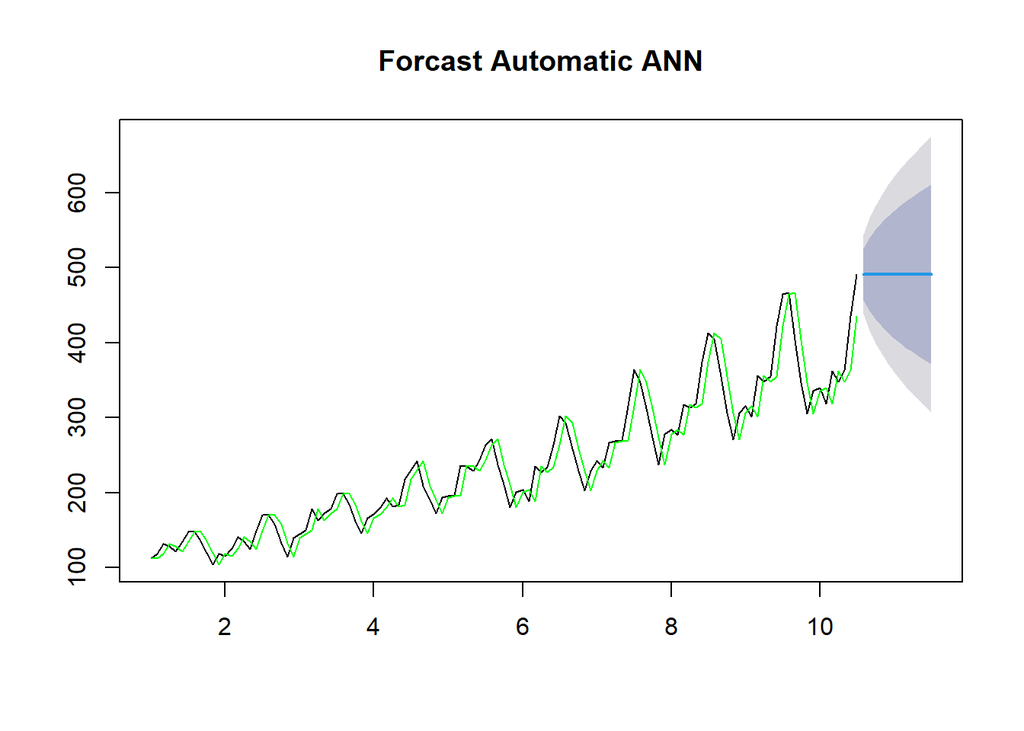

```r
# ploting Automatic ANN
frc <- forecast(fit, h=12)
plot(frc, main = "Forcast Automatic ANN")
lines(fit$fitted,col="green")
```

- Forecast ANN and Alpha M1

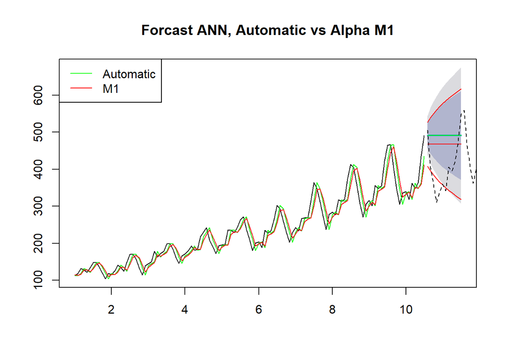

```r
# ploting M1 vs ANN
frc_m1 <- forecast(fit_m1,h=12)
plot(frc, main = "Forcast ANN, Automatic vs Alpha M1")
lines(frc$mean,col="green")
lines(fit$fitted,col="green")
lines(fit_m1$fitted,col="red")

lines(frc_m1$mean,col="red")
lines(frc_m1$lower[,2],col="red") # 95% lower
lines(frc_m1$upper[,2],col="red") # 95% upper
lines(y.tst,lty=2)

# legends
legend("topleft",c("Automatic","M1"),col=c("green","red"),lty=1)
```

- Forecast ANN and Alpha M2

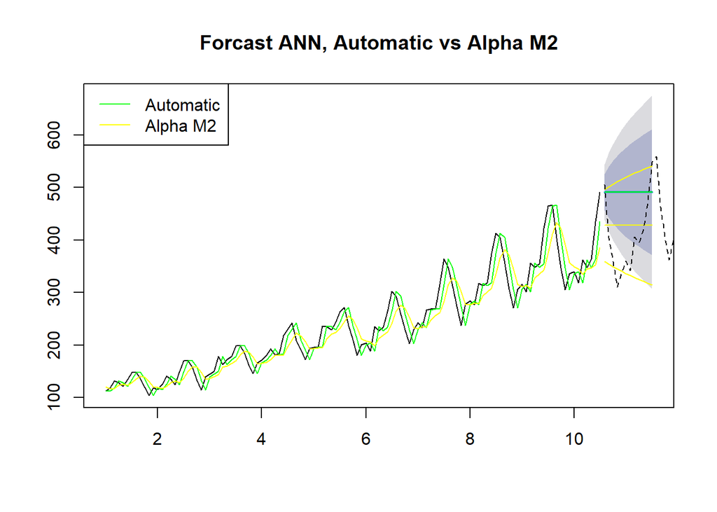

```r
# Ploting M2 vs ANN
frc_m2 <- forecast(fit_m2,h=12)
plot(frc, main = "Forcast ANN, Automatic vs Alpha M2")
lines(frc$mean,col="green")
lines(fit$fitted,col="green")
lines(fit_m2$fitted,col="yellow")

lines(frc_m2$mean,col="yellow")
lines(frc_m2$lower[,2],col="yellow") # 95% lower
lines(frc_m2$upper[,2],col="yellow") # 95% upper
lines(y.tst,lty=2)

# Add legend to the plot
legend("topleft",c("Automatic","Alpha M2"),col=c("green","yellow"),lty=1)
```

- Confidence level ANN, Alpha M1 and Alpha M2

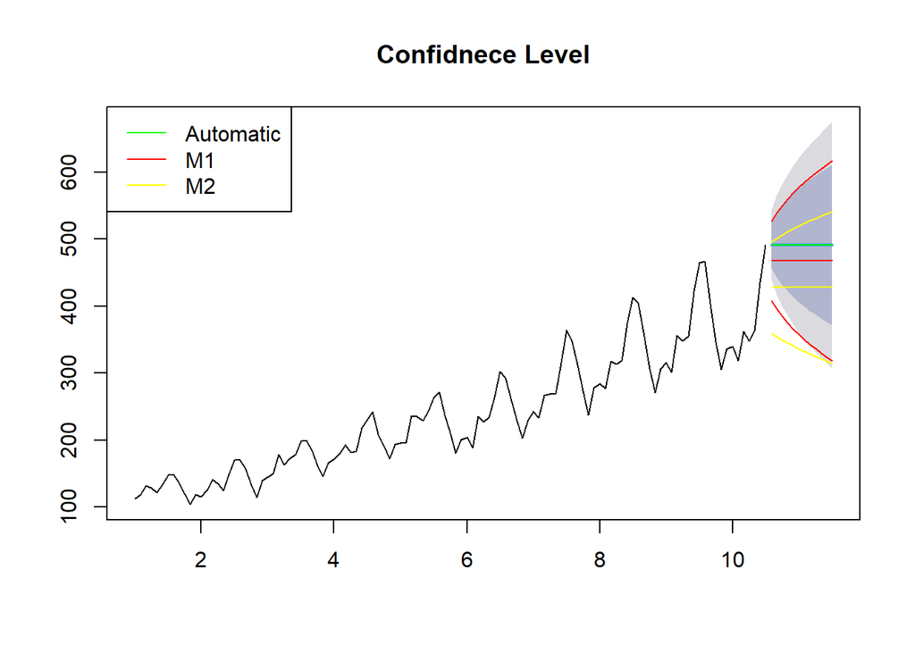

```r
# Ploting confidence level of all 3
plot(frc, main = "Confidnece Level")
lines(frc$mean,col="green")

lines(frc_m1$mean,col="red")
lines(frc_m1$lower[,2],col="red") # 95% lower
lines(frc_m1$upper[,2],col="red")

lines(frc_m2$mean,col="yellow")
lines(frc_m2$lower[,2],col="yellow") # 95% lower
lines(frc_m2$upper[,2],col="yellow") # 95% upper

# Add legend to the plot
legend("topleft",c("Automatic","M1","M2"),col=c("green","red","yellow"),lty=1)
```

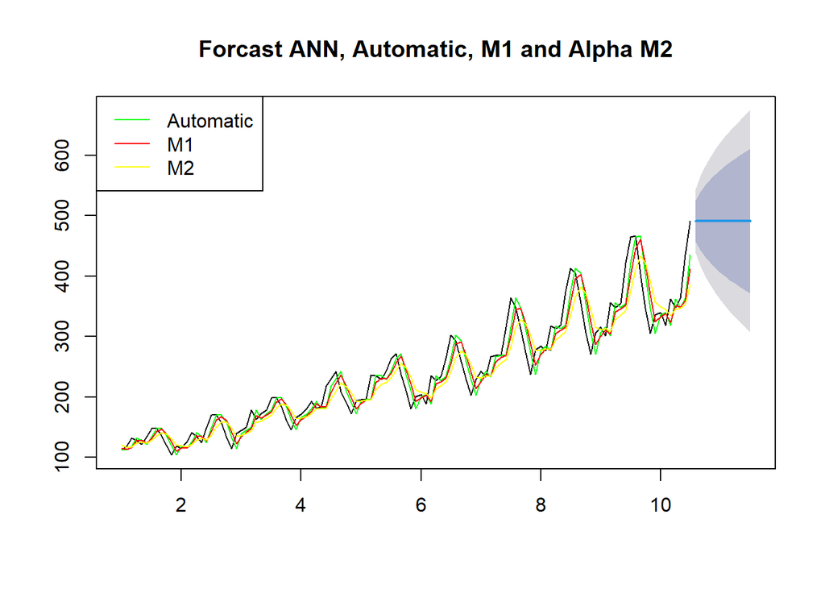

```r
plot(frc, main = "Forcast ANN, Automatic, M1 and Alpha M2")
lines(fit$fitted,col="green")
lines(fit_m1$fitted,col="red")
lines(fit_m2$fitted,col="yellow")
legend("topleft",c("Automatic","M1","M2"),col=c("green","red","yellow"),lty=1)
```

#### 4.3 Model selection

```r
# Function to calculate metrics
calculate_metrics <- function(y, frc) {
  MAE <- mean(abs(y - frc$mean))
  MSE <- mean((y - frc$mean)^2)
  RMSE <- sqrt(MSE)
  return(list(MAE = MAE, MSE = MSE, RMSE = RMSE))
}

# Calculate metrics for different forecasts
metrics_a <- calculate_metrics(y.tst, frc)
metrics_m1 <- calculate_metrics(y.tst, frc_m1)
metrics_m2 <- calculate_metrics(y.tst, frc_m2)

# Create a matrix for the metrics
metrics_matrix <- matrix(c(metrics_a$MAE, metrics_m1$MAE, metrics_m2$MAE,
                           metrics_a$RMSE, metrics_m1$RMSE, metrics_m2$RMSE,
                          metrics_a$MSE, metrics_m1$MSE, metrics_m2$MSE),
                          ncol = 3, byrow = TRUE)

# Add row and column names
rownames(metrics_matrix) <- c("MAE", "MSE", "RMSE")
colnames(metrics_matrix) <- c("Automatic", "Alpha M1", "Alpha M2")

# Display the metrics matrix
metrics_matrix
```

```
##        Automatic   Alpha M1   Alpha M2
## MAE     97.91293   82.91794   63.20054
## MSE    110.27141   92.98692   72.65461
## RMSE 12159.78442 8646.56703 5278.69264
```

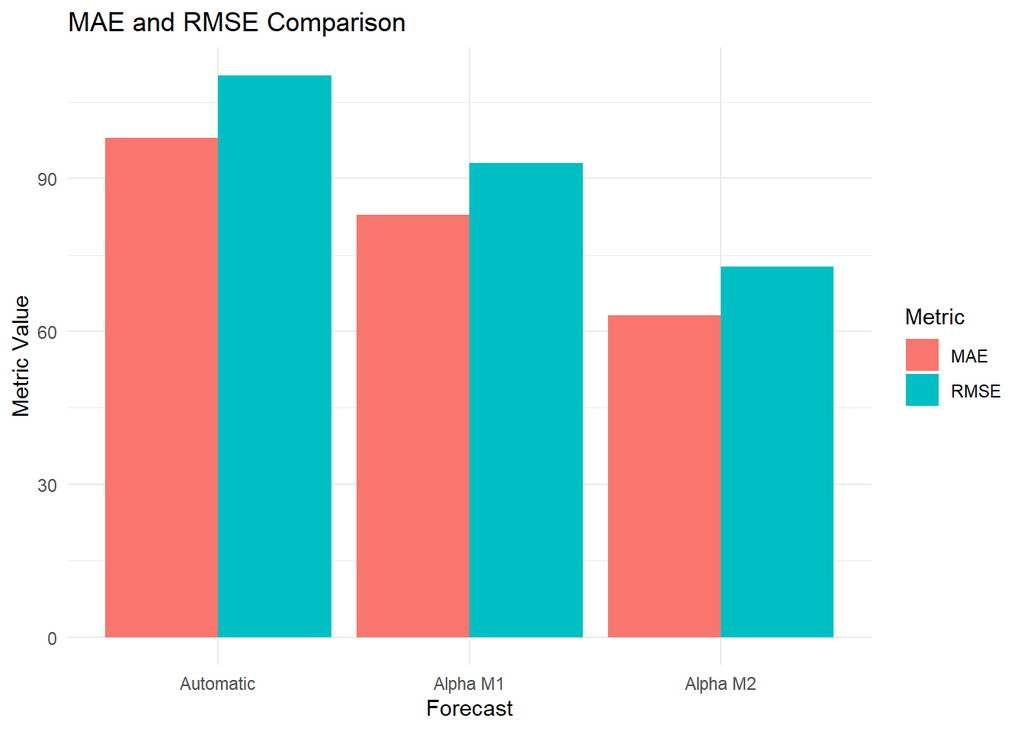

```r
# Create a data frame from the metrics matrix, excluding MSE
metrics_df <- data.frame(
  Metric = rep(c("MAE", "RMSE"), each = 3),
  Value = c(metrics_a$MAE, metrics_m1$MAE, metrics_m2$MAE,
            metrics_a$RMSE, metrics_m1$RMSE, metrics_m2$RMSE),
  Forecast = rep(c("Automatic", "Alpha M1", "Alpha M2"), times = 2)
)
metrics_df$Forecast <- factor(metrics_df$Forecast, levels = c("Automatic", "Alpha M1", "Alpha M2"))

# Create a bar plot
ggplot(metrics_df, aes(x = Forecast, y = Value, fill = Metric)) +
  geom_bar(stat = "identity", position = position_dodge()) +
  labs(title = "MAE and RMSE Comparison",
       y = "Metric Value") +
  theme_minimal()
```

### 5. Answers

- Which one is best using your judgement?

  Upon examining the in-sample data for the “AirPassengers” component, it becomes evident that **Model M1** effectively mitigates noise and outliers while achieving a robust fit compared to the Automatic model. Conversely, Model M2, while less successful in capturing seasonality during fitting, excels in noise and outlier reduction. The Automatic model, regrettably, does not effectively filter out noise and outliers.

  Given these insights, Model M1 emerges as the preferred choice due to its balanced approach, prioritizing noise reduction and fitting performance
- Which one is best using errors?

  When considering error metrics such as MSE and AIC, it becomes clear that the **Automatic** model performs better in terms of error minimization. This suggests that the Automatic model provides the most accurate predictions for the “AirPassengers” component within the in-sample data.
- Does the selected model perform best in the out-of-sample data?

  in the out-of-sample analysis, Model M1 does not prove to be the optimal choice. It does not yield the best RMSE and MAE values. Conversely, Model M2 exhibits superior performance in terms of these metrics.

  It is essential to acknowledge that while Model M1 excels in noise and outlier reduction and provides a strong fit within the in-sample data, its out-of-sample performance may differ. **Model M2**, despite its limitations in fitting seasonality, appears to generalize better to unseen data points when forecasting “AirPassengers.”